# What are estimands and why you should think about them?

Or why do statistics if you don’t even know what you want to estimate and whether its meaningful?

Jesse Brunner

## The problem

We often collect data and then hope statistics will give us answers, but…

- Answers to what question(s)?
- What are we trying to get at?
- What do want from our statistical output?

The answer is to define your estimand

“Every quantitative study must be able to answer the question: what is your estimand? The estimand is the target quantity—the purpose of the statistical analysis.”

– Lundberg, I., R. Johnson, and B. M. Stewart. 2021. What Is Your Estimand? Defining the Target Quantity Connects Statistical Evidence to Theory. American Sociological Review 86:532-565.

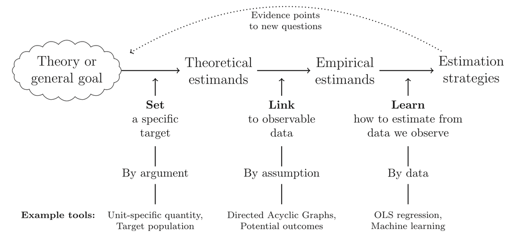

From Lundberg et al. 2021

## Theoretical estimand

What is the thing you want to learn or measure *without reference to the model or statistics?*

- Can be casual or descriptive or come from theory
- Can involve unobserved (or unobservable) variables

E.g., What is the maximum rate at which aquatic invertebrates can scavenge carcasses of long-toed salamander larvae (*Ambystoma macrodactylum*)? At what density of carcass is a single invertebrate saturated?

## Theoretical estimand

Two parts:

1. Unit-specific quantity (defined for each unit of observation in a population)
   - realized outcome
   - potential outcome
   - difference in potential outcomes with interventions

Estimate a scavenger’s maximum rate of carcass consumption and the carcass density at which they approach that maximum

## Theoretical estimand

Two parts:

1. Unit-specific quantity
2. Target population (i.e., what’s your inference about?)
   - empirically tractable
   - of theoretical interest itself
   - informative of a broader population (*address the tension*)

Focus on *Dytiscid* beetle larvae because they represent an extreme in scavenging rates & are common in ponds

## Empirical estimand

Links theoretical estimand to the data you actually observe

Requires some “identification assumptions” to help us understand what part(s) of the statistical estimation machinery relate to which theoretical influence.

E.g., *Dytiscid* larvae assigned *randomly* to carcass treatments. No other food sources or con/heterspecifics present that might affect scavenging rates.

## Empirical estimand

What are you estimating from the data? (e.g., a difference, a mean effect of $x$ on $y$ after accounting for $a$, $b$, and $c$; a slope, a maximum, …)

Want to estimate $a$ and $h$ in $\mu_i = \frac{ac_i}{1+ac_ih}$

## How do we do this?

**Theoretical estimand**

- Think carefully and ask the Big Question (what do you want to know/learn?)
- read the literature
- Talk to your advisor, colleagues, lab
- Draw pictures

## How do we do this?

**Empirical estimand**

- Draw pictures and graphs
- Consider what else affects the variable of interest (and thus might mess up your empirical estimand)
  - confounding, colliders, etc.
  - We will learn about DAGs later
- Simulate data and try methods